# Paul Skenes: Pitch Quality and Effectiveness

- Show All Code
- Hide All Code
- View Source

An exploratory study of arsenal changes, release characteristics, and secondary-pitch chase

Author

Andy Lucas

## Executive Summary

Skenes’s sampled 2026 results showed lower strikeout rates, higher walk rates, and more home runs than in 2025. The four-seamer accounted for most of the additional home runs, while the changeup and sweeper showed reduced chase and whiff rates. Release characteristics added predictive information about fastball velocity and movement in some test periods, but the improvement was inconsistent. A separate analysis found no clear, stable association between recent fastball velocity and secondary-pitch chase. The results identify several accompanying changes without establishing one definitive cause of the decline.

**NoteScope**

This is an exploratory analysis of regular-season data requested through **September 22, 2026**, compared with his full 2024 and 2025 regular seasons. The 2026 sample is near-complete and potentially excludes one remaining start; the reported results are those available through the cutoff.

## Research Questions and Working Hypotheses

The project asks what changed in Skenes’s pitch quality and results, and whether delivery measurements or fastball expectations help explain those changes. Two working hypotheses guide the modeling:

1. **Delivery and fastball shape:** Changes in release position, extension, or arm angle may be associated with changes in four-seam velocity and induced vertical break.
2. **Fastball expectations and chase:** Hitters preparing for a faster fastball may commit earlier, leaving them more susceptible to chasing secondary pitches outside the strike zone.

The second hypothesis concerns anticipation across encounters, not only the immediately preceding pitch. Pitchers may shape hitter expectations over multiple games; however, this dataset cannot establish deliberate long-term setup or directly observe a hitter’s decision process. These hypotheses developed during the analysis and are treated as exploratory explanations, not preregistered causal tests.

## Data and Methods

Pitch-level Statcast data were requested through `baseballr` for Skenes (MLBAM ID 694973). The requested windows are May 11–September 30, 2024; March 27–September 28, 2025; and March 26–September 22, 2026. Only regular-season records are retained. Duplicate pitch identifiers are removed, and cumulative outing pitch count is calculated before separating pitch types. The original workload groups are retained in the code for reproducibility, although the final article emphasizes seasonal comparisons.

The download chunk saves a timestamped RDS snapshot on its first run and reuses it on subsequent renders. The current snapshot preserves the original extraction and adds the remaining September 2024 and 2025 pitches downloaded after the end-date update. A fresh extraction may contain later Statcast revisions.

**Show R code**

```r
# To refresh deliberately, change this filename or archive the existing snapshot.
data_dir <- "data"
dir.create(data_dir, showWarnings = FALSE, recursive = TRUE)
snapshot_path <- file.path(data_dir, "skenes-full-2024-2025-through-2026-09-22.rds")

if (file.exists(snapshot_path)) {
  data_snapshot <- readRDS(snapshot_path)
  skenes <- data_snapshot$pitches
  extraction_time <- data_snapshot$extracted_at
  # Preserve the original per-season objects as well.
  skenes_2024 <- skenes |> filter(game_year == 2024)
  skenes_2025 <- skenes |> filter(game_year == 2025)
  skenes_2026 <- skenes |> filter(game_year == 2026)
} else {
  skenes_2024 <- statcast_search_pitchers(
    start_date = "2024-05-11",
    end_date = "2024-09-30",
    pitcherid = 694973)

  skenes_2025 <- statcast_search_pitchers(
    start_date = "2025-03-27",
    end_date = "2025-09-28",
    pitcherid = 694973)

  skenes_2026 <- statcast_search_pitchers(
    start_date = "2026-03-26",
    end_date = "2026-09-22",
    pitcherid = 694973)

  skenes <- bind_rows(skenes_2024, skenes_2025, skenes_2026)
  stopifnot(all(2024:2026 %in% unique(skenes$game_year)))
  extraction_time <- format(Sys.time(), tz = "UTC", usetz = TRUE)
  saveRDS(list(pitches = skenes, extracted_at = extraction_time), snapshot_path)
}
stopifnot(all(2024:2026 %in% unique(skenes$game_year)))
```

**Show R code**

```r
skenes_clean <- skenes |>
  filter(game_type == "R",
    !is.na(at_bat_number),
    !is.na(pitch_number)) |>
  distinct(
    game_pk, at_bat_number, pitch_number,
    .keep_all = TRUE) |>
  arrange(game_pk, at_bat_number, pitch_number) |>
  group_by(game_pk) |>
  mutate(
    game_pitch_number = row_number(),
    workload_group = case_when(
      game_pitch_number <= 25 ~ "1-25",
      game_pitch_number <= 50 ~ "26-50",
      game_pitch_number <= 75 ~ "51-75",
      TRUE ~ "76+")) |>
  ungroup() |>
  mutate(
    season = factor(game_year),
    workload_group = factor(
      workload_group,
      levels = c("1-25", "26-50", "51-75", "76+")))

# Identify swings, misses, and measured locations.
skenes_metrics <- skenes_clean |>
  mutate(
    swing = description %in% c(
      "swinging_strike",
      "swinging_strike_blocked",
      "foul",
      "foul_tip",
      "hit_into_play",
      "foul_bunt",
      "missed_bunt",
      "bunt_foul_tip"),

    whiff = description %in% c(
      "swinging_strike",
      "swinging_strike_blocked",
      "missed_bunt"),

    # Keep missing locations as missing.
    in_zone = case_when(
      is.na(zone) ~ NA,
      zone %in% 1:9 ~ TRUE,
      TRUE ~ FALSE),

    ball_in_play = description == "hit_into_play",

    # Movement in inches, following your previous document.
    induced_vertical_break = pfx_z * 12,
    horizontal_break = pfx_x * 12)

pitch_summary <- skenes_metrics |>
  filter(!is.na(pitch_type), pitch_type != "") |>
  group_by(season, pitch_type) |>
  summarise(
    pitches = n(),

    avg_velo = mean(release_speed, na.rm = TRUE),
    avg_spin = mean(release_spin_rate, na.rm = TRUE),

    avg_IVB = mean(
      induced_vertical_break, na.rm = TRUE),
    avg_horizontal_break = mean(
      horizontal_break, na.rm = TRUE),

    zone_rate = 100 * mean(in_zone, na.rm = TRUE),

    swings = sum(swing),
    whiffs = sum(whiff),

    outside_pitches = sum(!in_zone, na.rm = TRUE),
    outside_swings = sum(swing & !in_zone, na.rm = TRUE),

    measured_bip = sum(
      ball_in_play & !is.na(launch_speed),
      na.rm = TRUE),

    hard_hits = sum( ball_in_play & launch_speed >= 95, na.rm = TRUE),
    .groups = "drop") |>
  group_by(season) |>
  mutate(
    usage_rate = 100 * pitches / sum(pitches)) |>
  ungroup() |>
  mutate(
    whiff_rate = if_else(
      swings > 0, 100 * whiffs / swings, NA_real_),
    chase_rate = if_else(
      outside_pitches > 0, 100 * outside_swings / outside_pitches, NA_real_),
    hard_hit_rate = if_else(
      measured_bip > 0, 100 * hard_hits / measured_bip, NA_real_))
```

**Show R code**

```r
skenes_clean |>
  group_by(season) |>
  summarise(pitches = n(), outings = n_distinct(game_pk),
    first_date = min(as.Date(game_date)),
    last_date = max(as.Date(game_date)), .groups = "drop") |>
  knitr::kable(format = "html", digits = 0,
    caption = "Regular-season sample coverage",
    col.names = c("Season", "Pitches", "Outings", "First date", "Last date")) |>
  kableExtra::kable_styling(
    bootstrap_options = c("hover", "condensed", "responsive"),
    full_width = FALSE, position = "center", font_size = 13) |>
  kableExtra::row_spec(0, bold = TRUE, color = "black", background = "#F2C94C")
```

Regular-season sample coverage

| Season | Pitches | Outings | First date | Last date |
| --- | --- | --- | --- | --- |
| 2024 | 2127 | 23 | 2024-05-11 | 2024-09-28 |
| 2025 | 2997 | 32 | 2025-03-27 | 2025-09-24 |
| 2026 | 2794 | 31 | 2026-03-26 | 2026-09-18 |

### Metric Definitions

| Metric | Definition used here |
| --- | --- |
| Whiff rate | Swinging misses divided by swings; the retained swing definition includes bunt attempts. |
| Chase rate | Swings at pitches outside Statcast zones 1–9 divided by pitches outside those zones. Missing zones are excluded. |
| Hard-hit rate | Batted balls with exit velocity at least 95 mph divided by batted balls with available exit velocity. |
| IVB | `pfx_z × 12`, expressed as induced vertical break in inches. |
| Horizontal break | `pfx_x × 12`, signed from the catcher’s perspective. |
| Barrel rate | Statcast contact category 6 divided by batted balls with valid contact categories 1–6. |
| K%, BB%, HR% | Recorded completed plate-appearance outcomes divided by recorded completed plate appearances; walks include intentional walks and truncated plate appearances are excluded. |

These denominators differ: whiff rate is conditional on swinging, while hard-hit and barrel rates are conditional on contact. Zone rate and pitch location describe where a ball went, not whether it hit the intended target. The [Statcast field documentation](https://baseballsavant.mlb.com/csv-docs) also describes changes to plate-location references and strike-zone definitions in 2026; cross-season location comparisons require caution.

## How Did Performance Change?

### Overall Results

I first establish how results changed using strikeout, walk, and home-run rates. These complementary measures distinguish reduced strikeout production from walks and damaging contact; they are not interchangeable with an overall run-prevention statistic.

**Show R code**

```r
pa_results <- skenes_clean |>
  filter(
    !is.na(events),
    events != "",
    events != "truncated_pa") |>
  mutate(
    strikeout = events %in% c(
      "strikeout", "strikeout_double_play"),
    walk = events %in% c("walk", "intent_walk"),
    home_run = events == "home_run")

season_results <- pa_results |>
  group_by(season) |>
  summarise(
    plate_appearances = n(),
    strikeouts = sum(strikeout),
    walks = sum(walk),
    home_runs = sum(home_run),
    strikeout_rate = 100 * mean(strikeout),
    walk_rate = 100 * mean(walk),
    home_run_rate = 100 * mean(home_run),
    .groups = "drop") |>
  mutate(
    k_minus_bb = strikeout_rate - walk_rate)

season_results |>
  select(season, plate_appearances, strikeouts, walks, home_runs,
    strikeout_rate, walk_rate, k_minus_bb, home_run_rate) |>
  knitr::kable(format = "html", digits = 2,
    caption = "Plate-appearance results by season",
    col.names = c("Season", "PA", "K", "BB", "HR", "K%", "BB%", "K−BB%", "HR%")) |>
  kableExtra::kable_styling(
    bootstrap_options = c("hover", "condensed", "responsive"),
    full_width = FALSE, position = "center", font_size = 13) |>
  kableExtra::row_spec(0, bold = TRUE, color = "black", background = "#F2C94C")
```

Plate-appearance results by season

| Season | PA | K | BB | HR | K% | BB% | K−BB% | HR% |
| --- | --- | --- | --- | --- | --- | --- | --- | --- |
| 2024 | 514 | 170 | 32 | 10 | 33.07 | 6.23 | 26.85 | 1.95 |
| 2025 | 733 | 216 | 42 | 11 | 29.47 | 5.73 | 23.74 | 1.50 |
| 2026 | 689 | 192 | 47 | 19 | 27.87 | 6.82 | 21.04 | 2.76 |

From 2025 to 2026, strikeout rate fell from 29.5% to 27.9%, walk rate increased from 5.73% to 6.82%, and home-run rate increased from 1.50% to 2.76% in the sampled periods. These changes establish the performance question; they do not identify its cause.

### Arsenal Characteristics

Comparing each pitch separately distinguishes changes within a pitch from changes in pitch selection. Pitch groups below are ordered by 2026 usage, with seasons presented chronologically.

**Show R code**

```r
# Most-used pitches in 2026 first
pitch_order <- pitch_summary |>
  filter(season == "2026") |>
  arrange(desc(usage_rate)) |>
  pull(pitch_type)

pitch_table <- pitch_summary |>
  mutate(
    pitch_name = recode(
      pitch_type,
      "CH" = "Changeup",
      "CU" = "Curveball",
      "FF" = "Four-Seam Fastball",
      "FS" = "Splitter",
      "SI" = "Sinker",
      "SL" = "Slider",
      "ST" = "Sweeper"),
    pitch_order = match(pitch_type, pitch_order)) |>
  arrange(pitch_order, season)

# Preserve the same order for the table headings
pitch_groups <- pitch_table |>
  group_by(pitch_order, pitch_name) |>
  summarise(rows = n(), .groups = "drop") |>
  arrange(pitch_order) |>
  select(pitch_name, rows) |>
  deframe()
pitch_table |>
  select(
    season, pitches, usage_rate,
    avg_velo, avg_spin, avg_IVB, avg_horizontal_break,
    zone_rate, whiff_rate, chase_rate, hard_hit_rate) |>
  knitr::kable(
    format = "html",
    digits = 1,
    col.names = c(
      "Season", "Pitches", "Usage %",
      "Velo (mph)", "Spin (rpm)", "IVB (in)",
      "HB (in)", "Zone %", "Whiff %",
      "Chase %", "Hard-hit %"),
    caption = "Paul Skenes: Pitch Quality and Effectiveness by Season") |>
  kableExtra::kable_styling(
    bootstrap_options = c(
      "striped", "hover", "condensed", "responsive"),
    full_width = FALSE,
    position = "center",
    font_size = 13) |>
  kableExtra::row_spec(
    0,
    bold = TRUE,
    color = "black",
    background = "gold") |>
  kableExtra::pack_rows(
    index = pitch_groups,
    bold = TRUE,
    background = "lightgrey")
```

Paul Skenes: Pitch Quality and Effectiveness by Season

| Season | Pitches | Usage % | Velo (mph) | Spin (rpm) | IVB (in) | HB (in) | Zone % | Whiff % | Chase % | Hard-hit % |
| --- | --- | --- | --- | --- | --- | --- | --- | --- | --- | --- |
| **Four-Seam Fastball** |  |  |  |  |  |  |  |  |  |  |
| 2024 | 834 | 39.2 | 98.8 | 2243.6 | 10.6 | -14.4 | 58.9 | 20.1 | 22.7 | 48.7 |
| 2025 | 1167 | 38.9 | 98.2 | 2254.7 | 11.6 | -14.0 | 60.9 | 26.2 | 25.2 | 53.3 |
| 2026 | 1143 | 40.9 | 96.8 | 2172.6 | 13.0 | -12.5 | 52.6 | 27.2 | 33.2 | 45.6 |
| **Sweeper** |  |  |  |  |  |  |  |  |  |  |
| 2024 | 212 | 10.0 | 84.7 | 2348.2 | 5.5 | 11.6 | 46.2 | 20.4 | 25.4 | 26.9 |
| 2025 | 475 | 15.8 | 84.5 | 2332.9 | 5.7 | 11.4 | 53.7 | 31.1 | 26.8 | 19.2 |
| 2026 | 439 | 15.7 | 84.3 | 2330.2 | 5.7 | 10.3 | 51.5 | 25.7 | 22.1 | 22.4 |
| **Changeup** |  |  |  |  |  |  |  |  |  |  |
| 2024 | 114 | 5.4 | 87.3 | 2043.7 | 3.5 | -17.5 | 21.1 | 54.8 | 43.3 | 7.1 |
| 2025 | 326 | 10.9 | 88.7 | 1807.6 | 5.4 | -16.6 | 23.0 | 42.8 | 41.4 | 11.6 |
| 2026 | 347 | 12.4 | 88.7 | 1823.9 | 6.4 | -15.4 | 24.2 | 33.5 | 37.6 | 19.6 |
| **Sinker** |  |  |  |  |  |  |  |  |  |  |
| 2025 | 312 | 10.4 | 97.6 | 2268.1 | 6.4 | -17.5 | 49.0 | 15.3 | 35.2 | 49.3 |
| 2026 | 330 | 11.8 | 96.6 | 2150.6 | 7.3 | -17.0 | 53.6 | 12.0 | 26.1 | 44.8 |
| **Splitter** |  |  |  |  |  |  |  |  |  |  |
| 2024 | 603 | 28.4 | 94.0 | 1760.5 | 0.7 | -14.0 | 49.1 | 28.4 | 41.4 | 35.8 |
| 2025 | 405 | 13.5 | 93.7 | 1675.6 | 0.0 | -13.4 | 44.2 | 20.9 | 35.4 | 44.9 |
| 2026 | 286 | 10.2 | 93.2 | 1637.4 | 1.6 | -13.3 | 42.7 | 17.4 | 36.6 | 38.6 |
| **Slider** |  |  |  |  |  |  |  |  |  |  |
| 2024 | 132 | 6.2 | 86.6 | 2323.5 | 6.8 | 1.6 | 38.6 | 31.0 | 27.2 | 18.8 |
| 2025 | 168 | 5.6 | 85.3 | 2316.5 | 7.6 | 3.3 | 55.4 | 33.8 | 21.3 | 16.7 |
| 2026 | 239 | 8.6 | 86.6 | 2307.2 | 1.8 | 3.3 | 40.2 | 32.8 | 38.5 | 39.5 |
| **Curveball** |  |  |  |  |  |  |  |  |  |  |
| 2024 | 230 | 10.8 | 83.0 | 2509.5 | -3.9 | 7.1 | 47.0 | 33.7 | 25.4 | 22.2 |
| 2025 | 144 | 4.8 | 83.9 | 2438.0 | -2.6 | 6.2 | 37.5 | 40.8 | 23.3 | 44.4 |
| 2026 | 10 | 0.4 | 81.8 | 2421.9 | -7.9 | 10.9 | 40.0 | 20.0 | 16.7 | 0.0 |

**Show R code**

```r
# Select the six most-used pitches in 2026
main_pitches <- pitch_table |>
  filter(season == "2026") |>
  slice_max(usage_rate, n = 6, with_ties = FALSE) |>
  arrange(desc(usage_rate)) |>
  pull(pitch_name)

comparison_plot <- pitch_table |>
  filter(
    season %in% c("2025", "2026"),
    pitch_name %in% main_pitches) |>
  mutate(
    pitch_name = factor(
      pitch_name,
      levels = main_pitches)) |>
  select(
    season, pitch_name,
    avg_velo, avg_spin, avg_IVB,
    whiff_rate, chase_rate, hard_hit_rate) |>
  pivot_longer(
    cols = c(
      avg_velo, avg_spin, avg_IVB,
      whiff_rate, chase_rate, hard_hit_rate),
    names_to = "metric",
    values_to = "value") |>
  mutate(
    metric = factor(
      metric,
      levels = c(
        "avg_velo", "avg_spin", "avg_IVB",
        "whiff_rate", "chase_rate", "hard_hit_rate"),
      labels = c(
        "Velocity (mph)", "Spin (rpm)", "IVB (in)",
        "Whiff rate (%)", "Chase rate (%)", "Hard-hit rate (%)")))
```

**Show R code**

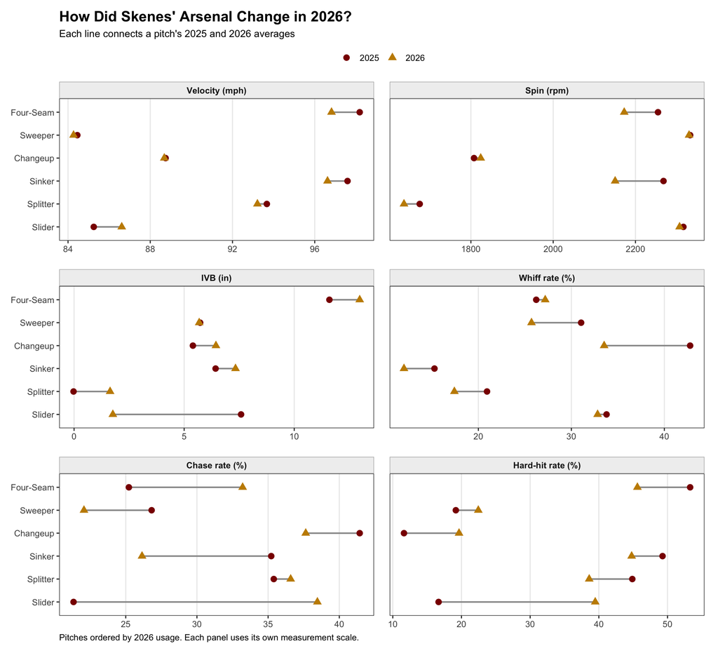

```r
ggplot(comparison_plot,
  aes(x = value, y = forcats::fct_rev(pitch_name))) +
  geom_line(
    aes(group = pitch_name),
    orientation = "y",
    color = "gray60",
    linewidth = 0.8) +
  geom_point(
    aes(color = season, shape = season),
    size = 3) +
  facet_wrap(
    ~ metric,
    scales = "free_x",
    ncol = 2) +
  scale_y_discrete(
    labels = c(
      "Four-Seam Fastball" = "Four-Seam",
      "Sweeper" = "Sweeper",
      "Changeup" = "Changeup",
      "Sinker" = "Sinker",
      "Splitter" = "Splitter",
      "Slider" = "Slider")) +
  scale_color_manual(
    values = c(
      "2025" = "darkred",
      "2026" = "#C58B00")) +
  scale_shape_manual(
    values = c(
      "2025" = 16,
      "2026" = 17)) +
  labs(
    title = "How Did Skenes' Arsenal Change in 2026?",
    subtitle = "Each line connects a pitch's 2025 and 2026 averages",
    x = NULL,
    y = NULL,
    color = "Season",
    shape = "Season",
    caption = paste(
      "Pitches ordered by 2026 usage.",
      "Each panel uses its own measurement scale.")) +
  theme_bw(base_size = 12) +
  theme(
    legend.position = "top",
    legend.title = element_blank(),
    panel.grid.major.y = element_blank(),
    panel.grid.minor = element_blank(),
    strip.background = element_rect(
      fill = "#F0F0F0",
      color = "gray70"),
    strip.text = element_text(face = "bold"),
    panel.spacing = grid::unit(1.2, "lines"),
    plot.title = element_text(face = "bold", size = 16),
    plot.subtitle = element_text(size = 11),
    plot.caption = element_text(hjust = 0),
    plot.margin = ggplot2::margin(12, 15, 12, 12))
```

The four-seamer slowed from 98.2 to 96.8 mph, but its own whiff and chase rates increased and its hard-hit rate decreased. That combination argues against describing the pitch as uniformly less effective. The changeup and sweeper, by contrast, both showed lower whiff and chase rates and higher hard-hit rates. The slider’s hard-hit increase warrants caution because its contact sample is small. The near-disappearance of the curveball also limits its year-to-year comparison.

### Contact Quality and Home Runs

Which pitches accounted for the additional home runs, and did they also allow harder contact on average? Home runs per 100 pitches accounts descriptively for pitch usage; it is a different denominator from home runs per plate appearance.

**Show R code**

```r
contact_summary <- skenes_metrics |>
  filter(!is.na(pitch_type), pitch_type != "") |>
  group_by(season, pitch_type) |>
  summarise(
    pitches = n(),
    home_runs = sum(events == "home_run", na.rm = TRUE),
    batted_balls = sum(ball_in_play, na.rm = TRUE),

    measured_bip = sum(
      ball_in_play & !is.na(launch_speed),
      na.rm = TRUE),

    avg_exit_velocity = mean(
      launch_speed[ball_in_play %in% TRUE],
      na.rm = TRUE),

    hard_hits = sum(
      ball_in_play & launch_speed >= 95,
      na.rm = TRUE),.groups = "drop") |>
  mutate(
    hard_hit_rate = if_else(
      measured_bip > 0,
      100 * hard_hits / measured_bip,
      NA_real_),
    hr_per_100_pitches = 100 * home_runs / pitches) |>
  arrange(pitch_type, season)
# Order pitches by 2026 usage
contact_order <- contact_summary |>
  filter(season == "2026") |>
  arrange(desc(pitches)) |>
  pull(pitch_type)

contact_table <- contact_summary |>
  mutate(
    pitch_name = recode(
      pitch_type,
      "CH" = "Changeup",
      "CU" = "Curveball",
      "FF" = "Four-Seam Fastball",
      "FS" = "Splitter",
      "SI" = "Sinker",
      "SL" = "Slider",
      "ST" = "Sweeper"),
    pitch_rank = match(pitch_type, contact_order)) |>
  arrange(pitch_rank, season)

contact_groups <- contact_table |>
  group_by(pitch_rank, pitch_name) |>
  summarise(rows = n(), .groups = "drop") |>
  arrange(pitch_rank) |>
  select(pitch_name, rows) |>
  deframe()

contact_table |>
  select(
    season,
    pitches,
    batted_balls,
    home_runs,
    avg_exit_velocity,
    hard_hit_rate,
    hr_per_100_pitches) |>
  knitr::kable(
    format = "html",
    digits = c(0, 0, 0, 0, 1, 1, 2),
    align = c("l", rep("c", 6)),
    col.names = c(
      "Season",
      "Pitches",
      "Batted Balls",
      "HR",
      "Avg. EV (mph)",
      "Hard-hit %",
      "HR / 100 Pitches"),
    caption = "Paul Skenes: Contact Quality by Pitch") |>
  kableExtra::kable_styling(
    bootstrap_options = c(
      "hover", "condensed", "responsive"),
    full_width = FALSE,
    position = "center",
    font_size = 13) |>
  kableExtra::row_spec(
    0,
    bold = TRUE,
    color = "black",
    background = "#F2C94C") |>
  kableExtra::row_spec(
    which(as.character(contact_table$season) == "2026"),
    bold = TRUE,
    background = "#FFF5D6") |>
  kableExtra::pack_rows(
    index = contact_groups,
    bold = TRUE,
    background = "#EEEEEE") |>
  kableExtra::footnote(
    general = paste(
      "Pitches ordered by 2026 usage.",
      "Hard-hit = exit velocity of at least 95 mph.",
      "Exit-velocity statistics exclude missing measurements."), general_title = "Note: ")
```

Paul Skenes: Contact Quality by Pitch

| Season | Pitches | Batted Balls | HR | Avg. EV (mph) | Hard-hit % | HR / 100 Pitches |
| --- | --- | --- | --- | --- | --- | --- |
| **Four-Seam Fastball** |  |  |  |  |  |  |
| 2024 | 834 | 113 | 5 | 91.0 | 48.7 | 0.60 |
| 2025 | 1167 | 167 | 5 | 91.5 | 53.3 | 0.43 |
| 2026 | 1143 | 171 | 12 | 89.9 | 45.6 | 1.05 |
| **Sweeper** |  |  |  |  |  |  |
| 2024 | 212 | 26 | 1 | 87.5 | 26.9 | 0.47 |
| 2025 | 475 | 73 | 1 | 81.0 | 19.2 | 0.21 |
| 2026 | 439 | 49 | 3 | 80.0 | 22.4 | 0.68 |
| **Changeup** |  |  |  |  |  |  |
| 2024 | 114 | 14 | 0 | 76.4 | 7.1 | 0.00 |
| 2025 | 326 | 43 | 0 | 77.8 | 11.6 | 0.00 |
| 2026 | 347 | 56 | 1 | 81.4 | 19.6 | 0.29 |
| **Sinker** |  |  |  |  |  |  |
| 2025 | 312 | 70 | 1 | 87.5 | 49.3 | 0.32 |
| 2026 | 330 | 67 | 2 | 89.5 | 44.8 | 0.61 |
| **Splitter** |  |  |  |  |  |  |
| 2024 | 603 | 110 | 1 | 87.5 | 35.8 | 0.17 |
| 2025 | 405 | 80 | 2 | 89.4 | 44.9 | 0.49 |
| 2026 | 286 | 57 | 0 | 86.6 | 38.6 | 0.00 |
| **Slider** |  |  |  |  |  |  |
| 2024 | 132 | 16 | 2 | 78.7 | 18.8 | 1.52 |
| 2025 | 168 | 18 | 0 | 84.0 | 16.7 | 0.00 |
| 2026 | 239 | 38 | 1 | 86.8 | 39.5 | 0.42 |
| **Curveball** |  |  |  |  |  |  |
| 2024 | 230 | 27 | 1 | 84.2 | 22.2 | 0.43 |
| 2025 | 144 | 18 | 2 | 90.5 | 44.4 | 1.39 |
| 2026 | 10 | 1 | 0 | 88.1 | 0.0 | 0.00 |

Note:  
Pitches ordered by 2026 usage. Hard-hit = exit velocity of at least 95 mph. Exit-velocity statistics exclude missing measurements.

The four-seam fastball accounted for most of Skenes’s increased home-run total in the sampled periods. Despite similar pitch counts in 2025 and 2026, home runs increased from five to 12, while average exit velocity fell from 91.5 to 89.9 mph and hard-hit rate declined from 53.3% to 45.6%. This suggests that average contact measures do not fully capture the additional damage. The following analysis examines whether the increased home-run damage was accompanied by changes in batted-ball type and barrel rate. Comparisons for less-used pitches require caution because their batted-ball samples are small.

**Show R code**

```r
fastball_damage <- skenes_metrics |>
  filter(
    pitch_type == "FF",
    ball_in_play %in% TRUE) |>
  group_by(season) |>
  summarise(
    batted_balls = n(),

    home_runs = sum(
      events == "home_run",
      na.rm = TRUE),

    classified_batted_balls = sum(
      bb_type %in% c(
        "ground_ball", "line_drive", "fly_ball", "popup")),

    ground_balls = sum(
      bb_type == "ground_ball",
      na.rm = TRUE),

    fly_balls = sum(
      bb_type == "fly_ball",
      na.rm = TRUE),

    barrel_eligible = sum(
      launch_speed_angle %in% 1:6),

    # Statcast contact category 6 = barrel
    barrels = sum(
      launch_speed_angle == 6,
      na.rm = TRUE),

    .groups = "drop") |>
  mutate(
    ground_ball_rate = if_else(
      classified_batted_balls > 0,
      100 * ground_balls / classified_batted_balls,
      NA_real_),

    fly_ball_rate = if_else(
      classified_batted_balls > 0,
      100 * fly_balls / classified_batted_balls,
      NA_real_),

    barrel_rate = if_else(
      barrel_eligible > 0,
      100 * barrels / barrel_eligible,
      NA_real_),

    hr_per_batted_ball = 100 * home_runs / batted_balls) |>
  arrange(season)
fastball_damage |>
  select(
    season,
    batted_balls,
    home_runs,
    barrels,
    ground_ball_rate,
    fly_ball_rate,
    barrel_rate,
    hr_per_batted_ball) |>
  knitr::kable(
    format = "html",
    digits = 1,
    align = c("l", rep("c", 7)),
    col.names = c(
      "Season",
      "Batted Balls",
      "Home Runs",
      "Barrels",
      "Ground Ball %",
      "Fly Ball %",
      "Barrel %",
      "HR / Batted Ball %"),
    caption = "Four-Seam Fastball: Contact Quality by Season") |>
  kableExtra::add_header_above(
    c(" " = 1,
      "Counts" = 3,
      "Contact Rates" = 4)) |>
  kableExtra::kable_styling(
    bootstrap_options = c("hover", "condensed", "responsive"),
    full_width = FALSE,
    position = "center",
    font_size = 14) |>
  kableExtra::row_spec(
    0,
    bold = TRUE,
    color = "black",
    background = "#F2C94C") |>
  kableExtra::row_spec(
    which(as.character(fastball_damage$season) == "2026"),
    bold = TRUE,
    background = "#FFF5D6")
```

Four-Seam Fastball: Contact Quality by Season

| Season | Counts Batted Balls | Counts Home Runs | Counts Barrels | Contact Rates Ground Ball % | Contact Rates Fly Ball % | Contact Rates Barrel % | Contact Rates HR / Batted Ball % |
| --- | --- | --- | --- | --- | --- | --- | --- |
| 2024 | 113 | 5 | 10 | 42.5 | 21.2 | 8.8 | 4.4 |
| 2025 | 167 | 5 | 13 | 31.7 | 34.1 | 7.8 | 3.0 |
| 2026 | 171 | 12 | 17 | 29.8 | 32.7 | 9.9 | 7.0 |

**Note:** Ground-ball and fly-ball rates use classified batted balls; fly balls exclude popups. Barrel rate uses batted balls with a valid Statcast contact classification. HR rate uses all batted balls.

Skenes’s four-seam home-run increase coincided with a higher barrel rate, but not a higher fly-ball rate. From 2025 to 2026, barrel rate increased from 7.8% to 9.9%, while home runs per batted ball rose from 3.0% to 7.0%. These results suggest that the additional damage was concentrated in a relatively small number of contacts. They do not establish whether reduced velocity, pitch location, opponent differences, or park conditions drove the increase.

## Did Release Characteristics Help Explain Fastball Changes?

### Season-Average Release Characteristics

Changes in release position, extension, and arm angle could accompany changes in fastball velocity and movement. I first compare seasonal averages, then test whether these measurements improve predictions beyond season and pitching context.

**Show R code**

```r
release_season <- skenes_metrics |>
  filter(pitch_type == "FF") |>
  group_by(season) |>
  summarise(
    release_side = mean(release_pos_x, na.rm = TRUE),
    release_height = mean(release_pos_z, na.rm = TRUE),
    extension = mean(release_extension, na.rm = TRUE),
    arm_angle = mean(arm_angle, na.rm = TRUE),
    .groups = "drop") |>
  arrange(season)

release_season |>
  knitr::kable(
    format = "html",
    digits = c(0, 2, 2, 2, 1),
    align = c("l", rep("c", 4)),
    col.names = c(
      "Season",
      "Horizontal Release (ft)",
      "Release Height (ft)",
      "Extension (ft)",
      "Arm Angle (°)"),
    caption = "Four-Seam Fastball: Average Release Characteristics") |>
  kableExtra::kable_styling(
    bootstrap_options = c("hover", "condensed", "responsive"),
    full_width = FALSE,
    position = "center",
    font_size = 13) |>
  kableExtra::row_spec(
    0,
    bold = TRUE,
    color = "black",
    background = "#F2C94C") |>
  kableExtra::row_spec(
    which(as.character(release_season$season) == "2026"),
    bold = TRUE,
    background = "#FFF5D6") |>
  kableExtra::footnote(
    general = paste(
      "Averages use individual four-seam pitches with available measurements.",
      "Horizontal release is measured from the catcher's perspective;",
      "negative values indicate the catcher's left."),
    general_title = "Note: ")
```

Four-Seam Fastball: Average Release Characteristics

| Season | Horizontal Release (ft) | Release Height (ft) | Extension (ft) | Arm Angle (°) |
| --- | --- | --- | --- | --- |
| 2024 | -2.26 | 5.70 | 6.43 | 24.5 |
| 2025 | -2.44 | 5.61 | 6.71 | 24.3 |
| 2026 | -2.36 | 5.62 | 6.77 | 26.5 |

Note:  
Averages use individual four-seam pitches with available measurements. Horizontal release is measured from the catcher's perspective; negative values indicate the catcher's left.

Skenes’s average four-seam arm angle increased from 24.3° in 2025 to 26.5° in 2026, while release height and extension changed relatively little. Over the same period, four-seam velocity declined from 98.2 to 96.8 mph, IVB increased from 11.6 to 13.0 inches, and horizontal movement became less negative, changing from −14.0 to −12.5 inches. These concurrent changes warrant investigating whether his delivery was associated with a different fastball shape. Season averages alone do not establish that the higher arm angle caused the velocity decline or increased home runs.

These are pitch-weighted averages and can conceal changes within a season. Horizontal release alone cannot distinguish a mechanical change from a change in positioning on the rubber. Arm angle and release height describe different aspects of delivery and need not move together.

### Velocity and IVB Models

For each outcome, I compare a context forest with a forest adding horizontal and vertical release position, extension, and arm angle. Context includes season, day of year, cumulative pitch count, days since the previous game, count, and batter handedness. Both models use the same complete-case sample and 1,000 trees with a fixed random seed. The final 10 eligible 2026 outings are held out intact; earlier pitches are used for training.

RMSE penalizes large errors more heavily; MAE describes average absolute error. Both are expressed in the outcome’s units: mph for velocity and inches for IVB. Errors are calculated within outings and then combined with equal weight per outing. These models assess same-pitch associations, not the effect of a mechanical intervention or a forecast based solely on pre-pitch information.

**Show R code**

```r
context_vars <- c(
  "season",
  "day_of_year",
  "game_pitch_number",
  "pitcher_days_since_prev_game",
  "balls",
  "strikes",
  "stand")

release_vars <- c(
  "release_pos_x",
  "release_pos_z",
  "release_extension",
  "arm_angle")

model_data <- skenes_metrics |>
  filter(pitch_type == "FF") |>
  mutate(
    game_date = as.Date(game_date),
    day_of_year = as.integer(format(game_date, "%j")),
    stand = factor(stand)) |>
  select(
    game_pk, game_date,
    all_of(context_vars),
    all_of(release_vars),
    release_speed,
    induced_vertical_break) |>
  drop_na()

# Check how many pitches remain in the complete-case sample
model_data |>
  count(season, name = "model_pitches") |>
  knitr::kable(format = "html", col.names = c("Season", "Complete-case pitches"),
    caption = "Four-seam model sample") |>
  kableExtra::kable_styling(full_width = FALSE)
```

Four-seam model sample

| Season | Complete-case pitches |
| --- | --- |
| 2024 | 801 |
| 2025 | 1132 |
| 2026 | 1130 |

**Show R code**

```r
# Reserve the last 10 outings of 2026 for testing
test_games <- model_data |>
  filter(season == "2026") |>
  distinct(game_pk, game_date) |>
  arrange(game_date, game_pk) |>
  slice_tail(n = 10)

stopifnot(nrow(test_games) == 10)

test_start <- min(test_games$game_date)

skenes_train <- model_data |>
  filter(game_date < test_start)

skenes_test <- model_data |>
  semi_join(test_games, by = "game_pk")

# Confirm the training and testing sets contain different outings
stopifnot(
  nrow(skenes_train) > 0,
  nrow(skenes_test) > 0,
  any(skenes_train$season == "2026"),
  length(intersect(
    skenes_train$game_pk,
    skenes_test$game_pk)) == 0)
```

**Show R code**

```r
set.seed(123)

rf_velocity_context <- randomForest(
  release_speed ~
    season +
    day_of_year +
    game_pitch_number +
    pitcher_days_since_prev_game +
    balls +
    strikes +
    stand,
  data = as.data.frame(skenes_train),
  ntree = 1000,
  importance = TRUE)

set.seed(123)

rf_velocity_release <- randomForest(
  release_speed ~
    season +
    day_of_year +
    game_pitch_number +
    pitcher_days_since_prev_game +
    balls +
    strikes +
    stand +
    release_pos_x +
    release_pos_z +
    release_extension +
    arm_angle,
  data = as.data.frame(skenes_train),
  ntree = 1000,
  importance = TRUE)
```

**Show R code**

```r
velocity_predictions <- skenes_test |>
  mutate(
    training_mean = mean(skenes_train$release_speed),

    context_prediction = as.numeric(
      predict(
        rf_velocity_context,
        newdata = as.data.frame(skenes_test))),

    release_prediction = as.numeric(
      predict(
        rf_velocity_release,
        newdata = as.data.frame(skenes_test))))

# Calculate errors within outings, then weight outings equally
velocity_results <- velocity_predictions |>
  select(
    game_pk,
    release_speed,
    training_mean,
    context_prediction,
    release_prediction) |>
  pivot_longer(
    cols = c(
      training_mean,
      context_prediction,
      release_prediction),
    names_to = "model",
    values_to = "predicted_velocity") |>
  group_by(model, game_pk) |>
  summarise(
    mse = mean((release_speed - predicted_velocity)^2),
    mae = mean(abs(release_speed - predicted_velocity)),
    .groups = "drop") |>
  group_by(model) |>
  summarise(
    RMSE = sqrt(mean(mse)),
    MAE = mean(mae),
    .groups = "drop") |>
  mutate(
    model = factor(
      model,
      levels = c(
        "training_mean",
        "context_prediction",
        "release_prediction"),
      labels = c(
        "Training Mean",
        "Context",
        "Context + Release"))) |>
  arrange(model)

velocity_results |>
  knitr::kable(
    format = "html",
    digits = 2,
    col.names = c("Model", "RMSE (mph)", "MAE (mph)"),
    caption = "Four-Seam Velocity: Test-Set Performance") |>
  kableExtra::kable_styling(
    bootstrap_options = c("hover", "condensed", "responsive"),
    full_width = FALSE,
    position = "center",
    font_size = 13) |>
  kableExtra::row_spec(
    0,
    bold = TRUE,
    color = "black",
    background = "#F2C94C") |>
  kableExtra::footnote(
    general = paste(
      "Evaluated on the final 10 available outings of 2026.",
      "Each outing receives equal weight.",
      "Lower errors indicate better predictions."),
    general_title = "Note: ")
```

Four-Seam Velocity: Test-Set Performance

| Model | RMSE (mph) | MAE (mph) |
| --- | --- | --- |
| Training Mean | 1.59 | 1.40 |
| Context | 0.94 | 0.74 |
| Context + Release | 0.87 | 0.68 |

Note:  
Evaluated on the final 10 available outings of 2026. Each outing receives equal weight. Lower errors indicate better predictions.

Adding release position, extension, and arm angle improved four-seam velocity predictions on the final 10 available outings of 2026. RMSE decreased from 0.94 to 0.87 mph, while MAE decreased from 0.74 to 0.68 mph. This suggests that release characteristics provide predictive information beyond season, workload, count, and batter handedness. However, this improvement does not establish that delivery changes caused the velocity decline or identify one release variable as responsible.

This result describes the final holdout only. The chronological validation below checks whether the improvement repeats in earlier periods.

The second comparison uses the same predictors and held-out outings, with IVB as the outcome.

**Show R code**

```r
set.seed(123)

rf_ivb_context <- randomForest(
  induced_vertical_break ~
    season +
    day_of_year +
    game_pitch_number +
    pitcher_days_since_prev_game +
    balls +
    strikes +
    stand,
  data = as.data.frame(skenes_train),
  ntree = 1000,
  importance = TRUE)

set.seed(123)

rf_ivb_release <- randomForest(
  induced_vertical_break ~
    season +
    day_of_year +
    game_pitch_number +
    pitcher_days_since_prev_game +
    balls +
    strikes +
    stand +
    release_pos_x +
    release_pos_z +
    release_extension +
    arm_angle,
  data = as.data.frame(skenes_train),
  ntree = 1000,
  importance = TRUE)
```

**Show R code**

```r
ivb_predictions <- skenes_test |>
  mutate(
    training_mean = mean(skenes_train$induced_vertical_break),

    context_prediction = as.numeric(
      predict(
        rf_ivb_context,
        newdata = as.data.frame(skenes_test))),

    release_prediction = as.numeric(
      predict(rf_ivb_release,
        newdata = as.data.frame(skenes_test))))

# Calculate pitch-level errors within outings,
# then give each outing equal weight.
ivb_results <- ivb_predictions |>
  select(
    game_pk,
    induced_vertical_break,
    training_mean,
    context_prediction,
    release_prediction) |>
  pivot_longer(
    cols = c(
      training_mean,
      context_prediction,
      release_prediction),
    names_to = "model",
    values_to = "predicted_ivb") |>
  group_by(model, game_pk) |>
  summarise(
    mse = mean((induced_vertical_break - predicted_ivb)^2),
    mae = mean(abs(induced_vertical_break - predicted_ivb)),
    .groups = "drop") |>
  group_by(model) |>
  summarise(
    RMSE = sqrt(mean(mse)),
    MAE = mean(mae),
    .groups = "drop") |>
  mutate(
    model = factor(
      model,
      levels = c(
        "training_mean",
        "context_prediction",
        "release_prediction"),
      labels = c(
        "Training Mean",
        "Context",
        "Context + Release"))) |>
  arrange(model)

ivb_results |>
  knitr::kable(
    format = "html",
    digits = 2,
    col.names = c("Model", "RMSE (in)", "MAE (in)"),
    caption = "Four-Seam IVB: Test-Set Performance") |>
  kableExtra::kable_styling(
    bootstrap_options = c("hover", "condensed", "responsive"),
    full_width = FALSE,
    position = "center",
    font_size = 13) |>
  kableExtra::row_spec(
    0,
    bold = TRUE,
    color = "black",
    background = "#F2C94C") |>
  kableExtra::row_spec(
    3,
    bold = TRUE,
    background = "#FFF5D6") |>
  kableExtra::footnote(
    general = paste(
      "Evaluated on the same final 10 available outings of 2026",
      "used for the velocity models. Each outing receives equal weight.",
      "Lower errors indicate better predictions."),
    general_title = "Note: ")
```

Four-Seam IVB: Test-Set Performance

| Model | RMSE (in) | MAE (in) |
| --- | --- | --- |
| Training Mean | 1.99 | 1.68 |
| Context | 1.66 | 1.36 |
| Context + Release | 1.54 | 1.23 |

Note:  
Evaluated on the same final 10 available outings of 2026 used for the velocity models. Each outing receives equal weight. Lower errors indicate better predictions.

Adding release position, extension, and arm angle improved four-seam IVB predictions on the final 10 available outings of 2026. RMSE decreased from 1.66 to 1.54 inches, while MAE decreased from 1.36 to 1.23 inches. Together with the velocity-model results, this suggests that release characteristics provide additional predictive information about Skenes’s fastball velocity and movement beyond season and pitching context. These findings do not establish which delivery changes caused the season-level differences or whether those changes caused poorer results.

### Chronological Validation

To assess consistency, I repeat the comparisons in two earlier test blocks as well as the original final holdout. The first five eligible 2026 outings are reserved before testing begins so season is represented in every training sample. Each model uses only outings preceding its test block, with model settings held fixed. Earlier test blocks are smaller than the final 10-outing block; training histories also differ. The date table below is calculated from the eligible model sample, not all appearances.

**Show R code**

```r
games_2026 <- model_data |>
  filter(season == "2026") |>
  distinct(game_pk, game_date) |>
  arrange(game_date, game_pk)

# Reserve five eligible 2026 outings before testing begins
remaining_games <- games_2026 |>
  slice(-(1:5))

stopifnot(nrow(remaining_games) >= 14)

# Keep the original final 10 outings unchanged
earlier_games <- remaining_games |>
  slice_head(n = nrow(remaining_games) - 10)

first_block_size <- floor(nrow(earlier_games) / 2)

validation_games <- bind_rows(
  earlier_games |>
    slice_head(n = first_block_size) |>
    mutate(period = "Earlier block 1"),

  earlier_games |>
    slice_tail(n = nrow(earlier_games) - first_block_size) |>
    mutate(period = "Earlier block 2"),

  remaining_games |>
    slice_tail(n = 10) |>
    mutate(period = "Original final block"))

validation_games |>
  group_by(period) |>
  summarise(
    first_date = min(game_date),
    last_date = max(game_date),
    outings = n(),
    .groups = "drop") |>
  knitr::kable(format = "html",
    col.names = c("Test period", "First date", "Last date", "Outings"),
    caption = "Chronological test periods") |>
  kableExtra::kable_styling(full_width = FALSE)
```

Chronological test periods

| Test period | First date | Last date | Outings |
| --- | --- | --- | --- |
| Earlier block 1 | 2026-04-30 | 2026-06-03 | 7 |
| Earlier block 2 | 2026-06-09 | 2026-07-19 | 8 |
| Original final block | 2026-07-25 | 2026-09-18 | 10 |

**Show R code**

```r
validate_forest <- function(target, outcome_label, period_label) {

  held_out_games <- validation_games |>
    filter(period == period_label)

  cutoff <- min(held_out_games$game_date)

  training_data <- model_data |>
    filter(game_date < cutoff)

  testing_data <- model_data |>
    semi_join(held_out_games, by = "game_pk")

  stopifnot(
    nrow(training_data) > 0,
    any(training_data$season == "2026"),
    n_distinct(testing_data$game_pk) == nrow(held_out_games))

  # Context model
  set.seed(123)

  context_model <- randomForest(
    formula = reformulate(context_vars, response = target),
    data = as.data.frame(training_data),
    ntree = 1000,
    mtry = max(1, floor(length(context_vars) / 3)),
    nodesize = 5,
    importance = TRUE)

  # Context + release model
  all_predictors <- c(context_vars, release_vars)

  set.seed(123)

  release_model <- randomForest(
    formula = reformulate(all_predictors, response = target),
    data = as.data.frame(training_data),
    ntree = 1000,
    mtry = max(1, floor(length(all_predictors) / 3)),
    nodesize = 5,
    importance = TRUE)

  predictions <- tibble(
    game_pk = testing_data$game_pk,
    actual = testing_data[[target]],

    Context = as.numeric(predict(
      context_model,
      newdata = as.data.frame(testing_data))),

    `Context + Release` = as.numeric(predict(
      release_model,
      newdata = as.data.frame(testing_data))))

  predictions |>
    pivot_longer(
      cols = c("Context", "Context + Release"),
      names_to = "model",
      values_to = "predicted") |>
    group_by(model, game_pk) |>
    summarise(
      mse = mean((actual - predicted)^2),
      mae = mean(abs(actual - predicted)),
      .groups = "drop") |>
    group_by(model) |>
    summarise(
      RMSE = sqrt(mean(mse)),
      MAE = mean(mae),
      .groups = "drop") |>
    mutate(
      outcome = outcome_label,
      period = period_label)}

validation_results <- purrr::map_dfr(
  unique(validation_games$period),
  function(period_label) {bind_rows(
      validate_forest(
        "release_speed", "Velocity (mph)", period_label),
      validate_forest(
        "induced_vertical_break", "IVB (in)", period_label))})
```

**Show R code**

```r
validation_table <- validation_results |>
  mutate(
    model = recode(
      model,
      "Context" = "context",
      "Context + Release" = "release")) |>
  pivot_wider(
    id_cols = c(outcome, period),
    names_from = model,
    values_from = c(RMSE, MAE),
    names_glue = "{.value}_{model}") |>
  mutate(
    rmse_improvement = 100 *
      (RMSE_context - RMSE_release) / RMSE_context,

    mae_improvement = 100 *
      (MAE_context - MAE_release) / MAE_context,

    period = factor(
      period,
      levels = c(
        "Earlier block 1",
        "Earlier block 2",
        "Original final block"))) |>
  arrange(outcome, period) |>
  select(
    outcome, period,
    RMSE_context, RMSE_release, rmse_improvement,
    MAE_context, MAE_release, mae_improvement)

validation_table |>
  knitr::kable(
    format = "html",
    digits = 2,
    col.names = c(
      "Outcome", "Test Period",
      "Context RMSE", "Release RMSE", "Improvement %",
      "Context MAE", "Release MAE", "Improvement %"),
    caption = "Chronological Validation: Do Release Measurements Help?") |>
  kableExtra::kable_styling(
    bootstrap_options = c("hover", "condensed", "responsive"),
    full_width = FALSE,
    font_size = 13) |>
  kableExtra::row_spec(
    0, bold = TRUE, color = "black", background = "#F2C94C") |>
  kableExtra::footnote(
    general = paste(
      "Earlier test blocks contain fewer outings; the final holdout contains 10. Training uses only earlier games.",
      "Each test outing receives equal weight.",
      "Positive improvement means lower error after adding release measurements."),
    general_title = "Note: ")
```

Chronological Validation: Do Release Measurements Help?

| Outcome | Test Period | Context RMSE | Release RMSE | Improvement % | Context MAE | Release MAE | Improvement % |
| --- | --- | --- | --- | --- | --- | --- | --- |
| IVB (in) | Earlier block 1 | 2.01 | 2.04 | -1.39 | 1.61 | 1.65 | -2.64 |
| IVB (in) | Earlier block 2 | 1.42 | 1.41 | 0.99 | 1.12 | 1.11 | 0.85 |
| IVB (in) | Original final block | 1.66 | 1.54 | 7.39 | 1.36 | 1.23 | 9.68 |
| Velocity (mph) | Earlier block 1 | 1.31 | 1.24 | 5.46 | 1.11 | 1.04 | 6.30 |
| Velocity (mph) | Earlier block 2 | 1.04 | 1.09 | -5.08 | 0.79 | 0.85 | -7.12 |
| Velocity (mph) | Original final block | 0.94 | 0.87 | 6.89 | 0.74 | 0.68 | 7.44 |

Note:  
Earlier test blocks contain fewer outings; the final holdout contains 10. Training uses only earlier games. Each test outing receives equal weight. Positive improvement means lower error after adding release measurements.

Chronological validation showed that the predictive value of release measurements varied across test periods. Adding release characteristics improved velocity predictions in two of three periods but worsened them in the middle period. For IVB, release measurements provided little or no improvement in the earlier periods, with the clearest benefit occurring in the final holdout. These findings suggest that release characteristics contained useful predictive information under some conditions, but do not establish a consistent explanation for the season-long changes in velocity or movement.

The percentages measure reductions in prediction error, not the proportion of the velocity decline explained. The windows are a consistency check rather than independent replications, and no uncertainty interval for error differences is estimated here. The variable-importance plot is retained in the technical appendix; it does not identify the direction or causal importance of a release change.

## Did Expected Fastball Velocity Relate to Secondary-Pitch Chase?

### Hypothesis and Measurement

My hypothesis was that hitters preparing for Skenes’s higher-velocity fastball had less time to distinguish it from secondary pitches, potentially making them more susceptible to chasing outside the zone. That expectation can exist before the first fastball of an outing and can develop across games, not merely within one at-bat.

I use the average four-seam velocity over the previous three starts as a proxy for the fastball a hitter might expect entering the game. Only earlier outings enter this average; the first three outings of each season are excluded. The prediction is that higher expected velocity is associated with greater chase odds on comparable secondary pitches.

The analysis includes outside-zone changeups, splitters, sliders, and sweepers with complete measurements. It models swings versus takes, not misses conditional on swinging. The rolling average is a proxy for preparation, not an observation of a hitter’s expectations or decision timing.

**Show R code**

```r
# Four-seam velocity by outing
fastball_history <- skenes_metrics |>
  filter(
    pitch_type == "FF",
    !is.na(release_speed)) |>
  mutate(game_date = as.Date(game_date)) |>
  group_by(season, game_pk, game_date) |>
  summarise(
    avg_fastball_velocity = mean(release_speed),
    .groups = "drop") |>
  arrange(season, game_date, game_pk) |>
  group_by(season) |>
  mutate(
    # Equal-weight average of the previous three outings.
    # First three outings of each season have no estimate.
    expected_fastball_velocity = (
      lag(avg_fastball_velocity, 1) +
      lag(avg_fastball_velocity, 2) +
      lag(avg_fastball_velocity, 3)) / 3) |>
  ungroup()

hypothesis_data <- skenes_metrics |>
  left_join(
    fastball_history |>
      select(game_pk, expected_fastball_velocity),
    by = "game_pk") |>
  filter(
    pitch_type %in% c("CH", "FS", "SL", "ST"),
    in_zone %in% FALSE,
    !is.na(description),
    description != "",
    sz_top > sz_bot) |>
  mutate(
    game_date = as.Date(game_date),
    chase = as.integer(swing),
    pitch_type = factor(pitch_type),
    stand = factor(stand),
    relative_height = (plate_z - sz_bot) / (sz_top - sz_bot)) |>
  select(
    game_pk, game_date, season,
    chase, expected_fastball_velocity,
    pitch_type, plate_x, relative_height,
    release_speed, induced_vertical_break,
    horizontal_break, balls, strikes,
    stand, game_pitch_number) |>
  drop_na()
```

**Show R code**

```r
hypothesis_data |>
  distinct(season, game_pk, expected_fastball_velocity) |>
  group_by(season) |>
  summarise(
    outings = n(),
    mean_expected_velocity = mean(expected_fastball_velocity),
    minimum = min(expected_fastball_velocity),
    maximum = max(expected_fastball_velocity),
    .groups = "drop") |>
  knitr::kable(
    format = "html", digits = 2,
    col.names = c("Season", "Outings", "Mean expected velocity", "Minimum", "Maximum"),
    caption = "Expected Fastball Velocity Available for Chase Analysis")
```

Expected Fastball Velocity Available for Chase Analysis

| Season | Outings | Mean expected velocity | Minimum | Maximum |
| --- | --- | --- | --- | --- |
| 2024 | 20 | 98.76 | 97.90 | 99.41 |
| 2025 | 29 | 98.20 | 97.86 | 98.59 |
| 2026 | 28 | 96.88 | 96.38 | 97.58 |

In the analyzed sample, the 2026 expected-velocity range does not overlap with those of the earlier seasons. Season adjustment therefore makes this primarily a comparison of velocity variation within seasons; it cannot cleanly separate the broad year-to-year decline from other seasonal changes.

### Logistic Regression Results

A logistic regression estimates the association between expected fastball velocity and chase, controlling for season, pitch type, location, secondary-pitch velocity and movement, count, batter handedness, and pitch count. Spline terms allow nonlinear location relationships. The analysis uses all eligible observations for exploratory association estimation rather than the random forests’ training/test split. Uncertainty is clustered by outing because pitches in a game share the same expected-fastball value; the confidence intervals use an approximate t reference with outing count minus one degrees of freedom.

An odds ratio above 1 indicates higher chase odds per 1 mph higher expected velocity; a value below 1 indicates lower odds. An interval containing 1 leaves the direction uncertain. Odds ratios are not percentage-point changes in chase probability.

**Show R code**

```r
chase_hypothesis_model <- glm(
  chase ~
    expected_fastball_velocity +
    season +
    pitch_type +
    splines::ns(plate_x, df = 3) +
    splines::ns(relative_height, df = 3) +
    release_speed +
    induced_vertical_break +
    horizontal_break +
    factor(balls) +
    factor(strikes) +
    stand +
    game_pitch_number,
  data = hypothesis_data,
  family = binomial(),
  na.action = na.fail)
```

**Show R code**

```r
cluster_covariance <- sandwich::vcovCL(
  chase_hypothesis_model,
  cluster = hypothesis_data$game_pk,
  type = "HC1")

term <- "expected_fastball_velocity"

estimate <- coef(chase_hypothesis_model)[term]
standard_error <- sqrt(diag(cluster_covariance))[term]

# Approximate inference using the number of outing clusters
outing_count <- n_distinct(hypothesis_data$game_pk)
critical_value <- qt(0.975, df = outing_count - 1)

hypothesis_results <- tibble(
  comparison = "1 mph higher expected fastball velocity",
  odds_ratio = exp(estimate),
  lower_95 = exp(estimate - critical_value * standard_error),
  upper_95 = exp(estimate + critical_value * standard_error),
  p_value = 2 * pt(
    abs(estimate / standard_error),
    df = outing_count - 1,
    lower.tail = FALSE))

hypothesis_results |>
  knitr::kable(
    format = "html",
    digits = 3,
    col.names = c(
      "Comparison", "Odds Ratio",
      "95% CI Lower", "95% CI Upper", "P-value"),
    caption = "Expected Fastball Velocity and Secondary-Pitch Chase") |>
  kableExtra::kable_styling(
    bootstrap_options = c("hover", "condensed", "responsive"),
    full_width = FALSE,
    font_size = 13) |>
  kableExtra::row_spec(
    0,
    bold = TRUE,
    color = "black",
    background = "#F2C94C")
```

Expected Fastball Velocity and Secondary-Pitch Chase

| Comparison | Odds Ratio | 95% CI Lower | 95% CI Upper | P-value |
| --- | --- | --- | --- | --- |
| 1 mph higher expected fastball velocity | 0.937 | 0.646 | 1.358 | 0.726 |

The primary estimate was 0.937 (95% CI: 0.646–1.358; p = 0.726). Higher expected fastball velocity was not clearly associated with increased secondary-pitch chase after adjustment. The estimate was uncertain and does not rule out the proposed relationship.

**NoteWhat this test cannot establish**

The model does not measure swing commitment, hitter-specific scouting expectations, intentional long-term setup, or pitch tunneling. It assumes a common expected-velocity association across the included secondary pitches and seasons. Holding secondary-pitch characteristics and location fixed targets a conditional association, not the total effect of an arsenal changing together.

### Sensitivity Checks

I test whether the association depends on a three- versus five-start history, separate linear time trends within each season, or inclusion of pitches near the recorded zone boundaries. The three- and five-start comparisons use the same five-start-eligible sample; the clearly-outside check is a subset of that sample. Its pitch-center threshold is 0.2 feet beyond a horizontal or vertical recorded zone edge, an analysis choice rather than an official strike-zone definition.

Statcast changed plate-location reference points and zone definitions in 2026. Relative-height normalization and exclusion of borderline pitches do not fully harmonize these measurements.

**Show R code**

```r
# Add a five-start average to the existing fastball history
fastball_history_check <- fastball_history |>
  arrange(season, game_date, game_pk) |>
  group_by(season) |>
  mutate(
    expected_fastball_5 = (
      lag(avg_fastball_velocity, 1) +
      lag(avg_fastball_velocity, 2) +
      lag(avg_fastball_velocity, 3) +
      lag(avg_fastball_velocity, 4) +
      lag(avg_fastball_velocity, 5)) / 5) |>
  ungroup()

# Rebuild the chase data, keeping the zone measurements
sensitivity_data <- skenes_metrics |>
  left_join(
    fastball_history_check |>
      select(
        game_pk,
        expected_fastball_velocity,
        expected_fastball_5),
    by = "game_pk") |>
  filter(
    pitch_type %in% c("CH", "FS", "SL", "ST"),
    in_zone %in% FALSE,
    !is.na(description),
    description != "",
    sz_top > sz_bot) |>
  mutate(
    game_date = as.Date(game_date),
    day_of_year = as.integer(format(game_date, "%j")),

    chase = as.integer(swing),
    pitch_type = factor(pitch_type),
    stand = factor(stand),

    relative_height =
      (plate_z - sz_bot) / (sz_top - sz_bot),

    # Same 0.2-foot margin used in the earlier chase analysis
    clearly_outside =
      abs(plate_x) > (17 / 24 + 0.2) |
      plate_z < (sz_bot - 0.2) |
      plate_z > (sz_top + 0.2)) |>
  select(
    game_pk, game_date, season, day_of_year,
    chase, expected_fastball_velocity,
    expected_fastball_5,
    pitch_type, plate_x, relative_height,
    release_speed, induced_vertical_break,
    horizontal_break, balls, strikes,
    stand, game_pitch_number, clearly_outside) |>
  drop_na()
```

**Show R code**

```r
# Three-start model refitted on the common sample
chase_three_start <- update(
  chase_hypothesis_model,
  data = sensitivity_data)

# Replace the three-start estimate with the five-start estimate
chase_five_start <- update(
  chase_three_start,
  . ~ . - expected_fastball_velocity + expected_fastball_5,
  data = sensitivity_data)

# Add a separate linear time trend for each season
chase_time_adjusted <- update(
  chase_three_start,
  . ~ . + day_of_year + season:day_of_year,
  data = sensitivity_data)

# Exclude pitches near the recorded zone boundaries
clear_sensitivity_data <- sensitivity_data |>
  filter(clearly_outside)

chase_clearly_outside <- update(
  chase_three_start,
  data = clear_sensitivity_data)
```

**Show R code**

```r
extract_chase_result <- function(model, data, term, label) {

  covariance <- sandwich::vcovCL(
    model,
    cluster = data$game_pk,
    type = "HC1")

  estimate <- unname(coef(model)[term])
  standard_error <- unname(sqrt(diag(covariance))[term])

  outings <- n_distinct(data$game_pk)
  critical_value <- qt(0.975, df = outings - 1)

  tibble(
    check = label,
    outings = outings,
    pitches = nobs(model),
    odds_ratio = exp(estimate),
    lower_95 = exp(estimate - critical_value * standard_error),
    upper_95 = exp(estimate + critical_value * standard_error),
    p_value = 2 * pt(
      abs(estimate / standard_error),
      df = outings - 1,
      lower.tail = FALSE))}

chase_sensitivity_results <- bind_rows(
  extract_chase_result(
    chase_three_start,
    sensitivity_data,
    "expected_fastball_velocity",
    "Three-start average"),
  extract_chase_result(
    chase_five_start,
    sensitivity_data,
    "expected_fastball_5",
    "Five-start average"),
  extract_chase_result(
    chase_time_adjusted,
    sensitivity_data,
    "expected_fastball_velocity",
    "Three-start + seasonal time trends"),
  extract_chase_result(
    chase_clearly_outside,
    clear_sensitivity_data,
    "expected_fastball_velocity",
    "Three-start: clearly outside only"))

chase_sensitivity_results |>
  knitr::kable(
    format = "html",
    digits = 3,
    col.names = c(
      "Check", "Outings", "Pitches",
      "Odds Ratio", "95% CI Lower", "95% CI Upper", "P-value"),
    caption = "Sensitivity Checks: Expected Fastball Velocity and Chase") |>
  kableExtra::kable_styling(
    bootstrap_options = c("hover", "condensed", "responsive"),
    full_width = FALSE,
    font_size = 13) |>
  kableExtra::row_spec(
    0, bold = TRUE, color = "black", background = "#F2C94C") |>
  kableExtra::footnote(
    general = paste(
      "Odds ratios represent 1 mph higher expected fastball velocity.",
      "All checks begin with the same five-start-eligible sample.",
      "Uncertainty is clustered by outing.",
      "The clearly-outside model uses a subset of that sample."),
    general_title = "Note: ")
```

Sensitivity Checks: Expected Fastball Velocity and Chase

| Check | Outings | Pitches | Odds Ratio | 95% CI Lower | 95% CI Upper | P-value |
| --- | --- | --- | --- | --- | --- | --- |
| Three-start average | 71 | 1779 | 1.012 | 0.681 | 1.504 | 0.952 |
| Five-start average | 71 | 1779 | 1.214 | 0.811 | 1.819 | 0.341 |
| Three-start + seasonal time trends | 71 | 1779 | 0.880 | 0.567 | 1.367 | 0.566 |
| Three-start: clearly outside only | 71 | 1603 | 0.827 | 0.557 | 1.226 | 0.338 |

Note:  
Odds ratios represent 1 mph higher expected fastball velocity. All checks begin with the same five-start-eligible sample. Uncertainty is clustered by outing. The clearly-outside model uses a subset of that sample.

The expected-fastball-velocity hypothesis was not consistently supported across sensitivity checks. Odds ratios ranged from 0.827 to 1.214, and all 95% confidence intervals included 1. The estimated direction varied with the averaging window, adjustment for seasonal time trends, and exclusion of borderline pitches. These results do not establish that higher expected fastball velocity increased secondary-pitch chase, although the wide confidence intervals leave meaningful positive and negative associations plausible.

The matched-sample three-start estimate differs from the original model because the first five rather than first three outings of each season must be excluded. The models are reported together rather than selecting the specification with the smallest p-value. Overlapping velocity-history windows and serial dependence between outings may not be fully addressed by outing-clustered uncertainty.

## Conclusions and Player-Development Implications

### Performance changed across several parts of the arsenal

Skenes’s sampled 2026 performance featured fewer strikeouts, more walks, and more home runs than in 2025. The four-seamer accounted for seven of the eight additional home runs, with 1,167 four-seam pitches in 2025 and 1,143 in 2026 and lower average exit velocity and hard-hit rate. The changeup and sweeper also showed reduced chase and whiff rates. The decline therefore cannot be summarized adequately by fastball velocity alone.

### Release measurements helped under some conditions

Average arm angle increased while four-seam velocity and movement changed. Adding release measurements improved predictions in the final holdout, but the benefit varied across chronological test periods. This is evidence of useful predictive relationships under some conditions, not proof that a particular delivery change caused poorer results.

### The fastball-expectation hypothesis remains unresolved

The tested proxy for expected fastball velocity did not show a clear, stable association with secondary-pitch chase. Sensitivity estimates varied in direction and retained wide confidence intervals. That finding does not establish that hitter anticipation is irrelevant; it describes what these measurements and models could resolve.

The findings support closer video and scouting review of fastball delivery, damaging-contact locations, and secondary-pitch recognition. They do not justify prescribing a specific arm-angle or mechanical adjustment from these data alone. A stronger causal account would need information about intended targets, hitter preparation, swing timing, and other factors not available here.

## Limitations

- **Sample coverage and selection:** The analysis covers nearly all of Skenes’s 2026 regular season through September 22, potentially excluding one remaining start. The 2024 and 2025 comparisons cover his full regular seasons, with 2024 beginning at his MLB debut. The samples therefore differ in season coverage and number of outings. Only one pitcher is studied; less-used pitches have small contact samples, and complete-case filtering can change the represented outings and pitches.
- **Observational evidence:** Opponents, parks, weather, health, catcher decisions, and tactical changes could contribute to the observed patterns. No injury or deliberate mechanical change is established by these models.
- **Command and hitter expectations:** Actual location does not reveal the intended target. Previous-start velocity is only a proxy for expectations; individual hitter exposure, reputation, swing commitment, and tunneling are not directly measured.
- **Measurement comparability:** Statcast changed location references and zone definitions in 2026. Pitch classifications may also evolve. Normalization and boundary exclusions do not eliminate these issues.
- **Release-model interpretation:** Release predictors are correlated and observed on the same pitch as velocity and movement. Importance rankings cannot isolate a mechanical cause. The models do not directly predict home runs or total effectiveness, and improved prediction is not the percentage of a performance decline explained.
- **Validation limits:** Test blocks differ in size and available training history. Later training samples include earlier test periods. Model settings were fixed rather than extensively tuned, and uncertainty for error differences was not quantified. Regression forests also have limited ability to extrapolate beyond training conditions.
- **Limited velocity overlap and model assumptions:** The expected-velocity range in 2026 does not overlap earlier seasons. Season-adjusted results primarily use within-season variation and assume a common conditional association across pitch types. Adjustment for pitch characteristics does not estimate every pathway through which an arsenal could influence hitters.
- **Exploratory testing and dependence:** Hypotheses developed during analysis, and several models were examined. Outing-clustered uncertainty addresses within-game dependence but not necessarily serial dependence across starts. The rolling history windows overlap. Uncertain results should not be interpreted as proof of no baseball effect.

## Sources and Reproducibility

- [Baseball Savant Statcast search](https://baseballsavant.mlb.com/statcast_search): pitch-level data source.
- [Statcast CSV documentation](https://baseballsavant.mlb.com/csv-docs): field definitions and measurement changes.
- [baseballr documentation](https://billpetti.github.io/baseballr/): data acquisition tools.
- [randomForest documentation](https://cran.r-project.org/package=randomForest): regression forests.
- [sandwich clustered covariance documentation](https://sandwich.r-forge.r-project.org/reference/vcovCL.html): outing-clustered uncertainty.

## Technical Appendix

### Model Summary and Variable Importance

The console summary below reports out-of-bag performance and is retained for technical transparency; the chronological holdouts are the primary evaluation. Permutation importance describes prediction reliance, not causal effects or direction. The default scaled importance scores should not be read as literal percentages of explained decline.

**Show R code**

```r
print(rf_velocity_release)
```

```
Call:
 randomForest(formula = release_speed ~ season + day_of_year +      game_pitch_number + pitcher_days_since_prev_game + balls +      strikes + stand + release_pos_x + release_pos_z + release_extension +      arm_angle, data = as.data.frame(skenes_train), ntree = 1000,      importance = TRUE)
               Type of random forest: regression
                     Number of trees: 1000
No. of variables tried at each split: 3

          Mean of squared residuals: 0.496103
                    % Var explained: 62.58
```

**Show R code**

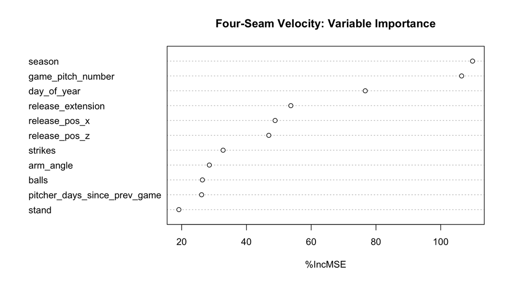

```r
varImpPlot(
  rf_velocity_release,
  type = 1,
  main = "Four-Seam Velocity: Variable Importance")
```